# Geographic Area Prediction

## Research Question

Can the geographic location be accurately predicted based on variables such as population density, net gain or loss of migrants, fertility rate, etc?

We are using this research question because the data we will be analyzing contains the populations of every country, along with other variables that could be used for predictions, such as population density and fertility rate. We will be analyzing these variables, along with others in the dataset, to try and accurately predict location based on only the other variables.

The context of this questions is predicting where(location) based on what(other factors, such as fertility rate, migrant movement).

Hypothesis:

Null hypothesis- The geographic location can be predicted based on these variables.

Alternate Hypothesis- The geographic location can not be predicted based on these variables.

I strongly believe that we will be able to accurately predict locations based on other variables. Some variables may have a stronger correlation with others, but this is what we will be finding in the analysis.

## Data Collection

The data gathered for this analysis is public use datasets from Kaggle. No challenges in collecting data, as all data sets used are public access. A problem with using data sets like this, is you have to work around the data provided. If you create your own dataset, you can gather exactly the data needed. A problem is finding datasets that correlate with eachother, so it takes lots of time searching for correct data sets that can be used in conjunction with eachother for an analysis. I finally came across datasets that can be linked by country and state, and therefore can all be used together.

Links:

https://www.kaggle.com/peretzcohen/2019-census-us-population-data-by-state

https://www.kaggle.com/tanuprabhu/population-by-country-2020

https://www.kaggle.com/paultimothymooney/latitude-and-longitude-for-every-country-and-state

### Data Explanation

https://www.kaggle.com/peretzcohen/2019-census-us-population-data-by-state

STATE: State in the US

POPESTIMATE2019: Population of State

lat: Lat Coordinate of Capital

long: Long Coordinate of Capital

https://www.kaggle.com/tanuprabhu/population-by-country-2020

Country: Country Name

Population (2020): Population Number

Yearly Change: Population yearly change

Net Change: Net change in population

Density (P/Km²): Population density

Land Area (Km²): Land area in square kilometers

Migrants (net): Net change in migrant population

Fert. Rate: Fertility Rate

Med. Age: Median Age

Urban Pop %: Percentage of population in urban areas

https://www.kaggle.com/paultimothymooney/latitude-and-longitude-for-every-country-and-state

country_code: Abbreviated country name

latitude: latitude of country

longitude: longitude of country

country: Full country name

usa_state_code: Abbreviated US states

usa_state_latitude: Latitude of US State

usa_state_longitude: Longitude of US State

usa_state: Full state name

## Data Extraction and Preparation

The tools imported below are the tools used for data extraction and preparation. Numpy is used for addition data science functionality. Pandas is used to create and manipulate dataframes. These tools have the benefit of being simple to use and providing a lot of extra usage and functionality. A disadvantage is using pandas dataframe, because once the data is converted into a dataframe, we have to use only tools that cooperate with the pandas dataframe object type.

```python
# Importing packages to be used
# numpy for data analysis functionality
import numpy as np
import warnings
warnings.simplefilter(action='ignore', category=FutureWarning)
# pandas for dataframes
import pandas as pd
# matplotlib for plotting
import matplotlib.pyplot as plt
%matplotlib inline
# seaborn for extra plotting functionality
import seaborn as sns
# Folium for map
import folium
from folium.plugins import MarkerCluster
# chain for map
from itertools import chain
import os
# proj_lib for basemap functionality
os.environ['PROJ_LIB'] = r'C:\Users\Thoma\anaconda3\Library\share\basemap'
from mpl_toolkits.basemap import Basemap
```

```python
# Importing datasets
usdf = pd.read_csv('Data\Census_US_Population_Data_By_State_Lat_Long_2019.csv')
popdf = pd.read_csv('Data\population_by_country_2020.csv')
locdf = pd.read_csv('Data\world_country_and_usa_states_latitude_and_longitude_values.csv')
```

```python
# Showing datasets
usdf.head()
```

|  | STATE | POPESTIMATE2019 | lat | long |
| --- | --- | --- | --- | --- |
| 0 | Alabama | 4903185 | 32.377716 | -86.300568 |
| 1 | Alaska | 731545 | 58.301598 | -134.420212 |
| 2 | Arizona | 7278717 | 33.448143 | -112.096962 |
| 3 | Arkansas | 3017804 | 34.746613 | -92.288986 |
| 4 | California | 39512223 | 38.576668 | -121.493629 |

```python
popdf.head()
```

|  | Country (or dependency) | Population (2020) | Yearly Change | Net Change | Density (P/Km²) | Land Area (Km²) | Migrants (net) | Fert. Rate | Med. Age | Urban Pop % | World Share |
| --- | --- | --- | --- | --- | --- | --- | --- | --- | --- | --- | --- |
| 0 | China | 1440297825 | 0.39 % | 5540090 | 153 | 9388211 | -348399.0 | 1.7 | 38 | 61 % | 18.47 % |
| 1 | India | 1382345085 | 0.99 % | 13586631 | 464 | 2973190 | -532687.0 | 2.2 | 28 | 35 % | 17.70 % |
| 2 | United States | 331341050 | 0.59 % | 1937734 | 36 | 9147420 | 954806.0 | 1.8 | 38 | 83 % | 4.25 % |
| 3 | Indonesia | 274021604 | 1.07 % | 2898047 | 151 | 1811570 | -98955.0 | 2.3 | 30 | 56 % | 3.51 % |
| 4 | Pakistan | 221612785 | 2.00 % | 4327022 | 287 | 770880 | -233379.0 | 3.6 | 23 | 35 % | 2.83 % |

```python
locdf.head()
```

|  | country_code | latitude | longitude | country | usa_state_code | usa_state_latitude | usa_state_longitude | usa_state |
| --- | --- | --- | --- | --- | --- | --- | --- | --- |
| 0 | AD | 42.546245 | 1.601554 | Andorra | AK | 63.588753 | -154.493062 | Alaska |
| 1 | AE | 23.424076 | 53.847818 | United Arab Emirates | AL | 32.318231 | -86.902298 | Alabama |
| 2 | AF | 33.939110 | 67.709953 | Afghanistan | AR | 35.201050 | -91.831833 | Arkansas |
| 3 | AG | 17.060816 | -61.796428 | Antigua and Barbuda | AZ | 34.048928 | -111.093731 | Arizona |
| 4 | AI | 18.220554 | -63.068615 | Anguilla | CA | 36.778261 | -119.417932 | California |

```python
# Splitting locdf into two different dataframes, for country and US
clocdf = locdf[['country_code','latitude','longitude','country']].copy()
ulocdf = locdf[['usa_state_code','usa_state_latitude','usa_state_longitude','usa_state']].copy()
```

### Merging US Data

```python
# New country df
clocdf.head()
```

|  | country_code | latitude | longitude | country |
| --- | --- | --- | --- | --- |
| 0 | AD | 42.546245 | 1.601554 | Andorra |
| 1 | AE | 23.424076 | 53.847818 | United Arab Emirates |
| 2 | AF | 33.939110 | 67.709953 | Afghanistan |
| 3 | AG | 17.060816 | -61.796428 | Antigua and Barbuda |
| 4 | AI | 18.220554 | -63.068615 | Anguilla |

```python
# New us df
ulocdf.head()
```

|  | usa_state_code | usa_state_latitude | usa_state_longitude | usa_state |
| --- | --- | --- | --- | --- |
| 0 | AK | 63.588753 | -154.493062 | Alaska |
| 1 | AL | 32.318231 | -86.902298 | Alabama |
| 2 | AR | 35.201050 | -91.831833 | Arkansas |
| 3 | AZ | 34.048928 | -111.093731 | Arizona |
| 4 | CA | 36.778261 | -119.417932 | California |

```python
# Renaming 'usa_state' column to 'STATE' so we can merge with other dataframe
ulocdf.rename(columns={'usa_state': 'STATE'}, inplace=True)
```

```python
# Checking df state name
ulocdf.head()
```

|  | usa_state_code | usa_state_latitude | usa_state_longitude | STATE |
| --- | --- | --- | --- | --- |
| 0 | AK | 63.588753 | -154.493062 | Alaska |
| 1 | AL | 32.318231 | -86.902298 | Alabama |
| 2 | AR | 35.201050 | -91.831833 | Arkansas |
| 3 | AZ | 34.048928 | -111.093731 | Arizona |
| 4 | CA | 36.778261 | -119.417932 | California |

```python
# Merging both US dataframes
newusdf= usdf.merge(ulocdf, on="STATE", how = 'inner')
```

```python
# Checking new dataframe
newusdf.head()
```

|  | STATE | POPESTIMATE2019 | lat | long | usa_state_code | usa_state_latitude | usa_state_longitude |
| --- | --- | --- | --- | --- | --- | --- | --- |
| 0 | Alabama | 4903185 | 32.377716 | -86.300568 | AL | 32.318231 | -86.902298 |
| 1 | Alaska | 731545 | 58.301598 | -134.420212 | AK | 63.588753 | -154.493062 |
| 2 | Arizona | 7278717 | 33.448143 | -112.096962 | AZ | 34.048928 | -111.093731 |
| 3 | Arkansas | 3017804 | 34.746613 | -92.288986 | AR | 35.201050 | -91.831833 |
| 4 | California | 39512223 | 38.576668 | -121.493629 | CA | 36.778261 | -119.417932 |

```python
# Removing the lat and long because we already have another lat/long column from merging
finalusdf = newusdf[['STATE','usa_state_code','usa_state_latitude','usa_state_longitude','POPESTIMATE2019']].copy()
```

```python
# Checking final us dataframe
finalusdf.head()
```

|  | STATE | usa_state_code | usa_state_latitude | usa_state_longitude | POPESTIMATE2019 |
| --- | --- | --- | --- | --- | --- |
| 0 | Alabama | AL | 32.318231 | -86.902298 | 4903185 |
| 1 | Alaska | AK | 63.588753 | -154.493062 | 731545 |
| 2 | Arizona | AZ | 34.048928 | -111.093731 | 7278717 |
| 3 | Arkansas | AR | 35.201050 | -91.831833 | 3017804 |
| 4 | California | CA | 36.778261 | -119.417932 | 39512223 |

### Merging country data

```python
# Country dataframe
clocdf.head()
```

|  | country_code | latitude | longitude | country |
| --- | --- | --- | --- | --- |
| 0 | AD | 42.546245 | 1.601554 | Andorra |
| 1 | AE | 23.424076 | 53.847818 | United Arab Emirates |
| 2 | AF | 33.939110 | 67.709953 | Afghanistan |
| 3 | AG | 17.060816 | -61.796428 | Antigua and Barbuda |
| 4 | AI | 18.220554 | -63.068615 | Anguilla |

```python
# Other Country Dataframe
popdf.head()
```

|  | Country (or dependency) | Population (2020) | Yearly Change | Net Change | Density (P/Km²) | Land Area (Km²) | Migrants (net) | Fert. Rate | Med. Age | Urban Pop % | World Share |
| --- | --- | --- | --- | --- | --- | --- | --- | --- | --- | --- | --- |
| 0 | China | 1440297825 | 0.39 % | 5540090 | 153 | 9388211 | -348399.0 | 1.7 | 38 | 61 % | 18.47 % |
| 1 | India | 1382345085 | 0.99 % | 13586631 | 464 | 2973190 | -532687.0 | 2.2 | 28 | 35 % | 17.70 % |
| 2 | United States | 331341050 | 0.59 % | 1937734 | 36 | 9147420 | 954806.0 | 1.8 | 38 | 83 % | 4.25 % |
| 3 | Indonesia | 274021604 | 1.07 % | 2898047 | 151 | 1811570 | -98955.0 | 2.3 | 30 | 56 % | 3.51 % |
| 4 | Pakistan | 221612785 | 2.00 % | 4327022 | 287 | 770880 | -233379.0 | 3.6 | 23 | 35 % | 2.83 % |

```python
# Renaming country columns to match for merging
clocdf.rename(columns={'country': 'Country'}, inplace=True)
popdf.rename(columns={'Country (or dependency)': 'Country'}, inplace=True)
```

```python
# Checking rename
clocdf.head()
```

|  | country_code | latitude | longitude | Country |
| --- | --- | --- | --- | --- |
| 0 | AD | 42.546245 | 1.601554 | Andorra |
| 1 | AE | 23.424076 | 53.847818 | United Arab Emirates |
| 2 | AF | 33.939110 | 67.709953 | Afghanistan |
| 3 | AG | 17.060816 | -61.796428 | Antigua and Barbuda |
| 4 | AI | 18.220554 | -63.068615 | Anguilla |

```python
# Checking rename
popdf.head()
```

|  | Country | Population (2020) | Yearly Change | Net Change | Density (P/Km²) | Land Area (Km²) | Migrants (net) | Fert. Rate | Med. Age | Urban Pop % | World Share |
| --- | --- | --- | --- | --- | --- | --- | --- | --- | --- | --- | --- |
| 0 | China | 1440297825 | 0.39 % | 5540090 | 153 | 9388211 | -348399.0 | 1.7 | 38 | 61 % | 18.47 % |
| 1 | India | 1382345085 | 0.99 % | 13586631 | 464 | 2973190 | -532687.0 | 2.2 | 28 | 35 % | 17.70 % |
| 2 | United States | 331341050 | 0.59 % | 1937734 | 36 | 9147420 | 954806.0 | 1.8 | 38 | 83 % | 4.25 % |
| 3 | Indonesia | 274021604 | 1.07 % | 2898047 | 151 | 1811570 | -98955.0 | 2.3 | 30 | 56 % | 3.51 % |
| 4 | Pakistan | 221612785 | 2.00 % | 4327022 | 287 | 770880 | -233379.0 | 3.6 | 23 | 35 % | 2.83 % |

```python
# Merging both country dataframes
newcountrydf= popdf.merge(clocdf, on="Country", how = 'inner')
```

```python
# Checking new dataframe
newcountrydf.head()
```

|  | Country | Population (2020) | Yearly Change | Net Change | Density (P/Km²) | Land Area (Km²) | Migrants (net) | Fert. Rate | Med. Age | Urban Pop % | World Share | country_code | latitude | longitude |
| --- | --- | --- | --- | --- | --- | --- | --- | --- | --- | --- | --- | --- | --- | --- |
| 0 | China | 1440297825 | 0.39 % | 5540090 | 153 | 9388211 | -348399.0 | 1.7 | 38 | 61 % | 18.47 % | CN | 35.861660 | 104.195397 |
| 1 | India | 1382345085 | 0.99 % | 13586631 | 464 | 2973190 | -532687.0 | 2.2 | 28 | 35 % | 17.70 % | IN | 20.593684 | 78.962880 |
| 2 | United States | 331341050 | 0.59 % | 1937734 | 36 | 9147420 | 954806.0 | 1.8 | 38 | 83 % | 4.25 % | US | 37.090240 | -95.712891 |
| 3 | Indonesia | 274021604 | 1.07 % | 2898047 | 151 | 1811570 | -98955.0 | 2.3 | 30 | 56 % | 3.51 % | ID | -0.789275 | 113.921327 |
| 4 | Pakistan | 221612785 | 2.00 % | 4327022 | 287 | 770880 | -233379.0 | 3.6 | 23 | 35 % | 2.83 % | PK | 30.375321 | 69.345116 |

```python
# Renaming population
newcountrydf.rename(columns={'Population (2020)': 'Population'}, inplace=True)
```

```python
# Sorting columns to be easier to view
finalcountydf = newcountrydf[['Country','country_code','latitude','longitude','Population','Yearly Change','Net Change','Density (P/Km²)','Land Area (Km²)','Migrants (net)','Fert. Rate','Med. Age','Urban Pop %','World Share']]
```

```python
finalcountydf.head()
```

|  | Country | country_code | latitude | longitude | Population | Yearly Change | Net Change | Density (P/Km²) | Land Area (Km²) | Migrants (net) | Fert. Rate | Med. Age | Urban Pop % | World Share |
| --- | --- | --- | --- | --- | --- | --- | --- | --- | --- | --- | --- | --- | --- | --- |
| 0 | China | CN | 35.861660 | 104.195397 | 1440297825 | 0.39 % | 5540090 | 153 | 9388211 | -348399.0 | 1.7 | 38 | 61 % | 18.47 % |
| 1 | India | IN | 20.593684 | 78.962880 | 1382345085 | 0.99 % | 13586631 | 464 | 2973190 | -532687.0 | 2.2 | 28 | 35 % | 17.70 % |
| 2 | United States | US | 37.090240 | -95.712891 | 331341050 | 0.59 % | 1937734 | 36 | 9147420 | 954806.0 | 1.8 | 38 | 83 % | 4.25 % |
| 3 | Indonesia | ID | -0.789275 | 113.921327 | 274021604 | 1.07 % | 2898047 | 151 | 1811570 | -98955.0 | 2.3 | 30 | 56 % | 3.51 % |
| 4 | Pakistan | PK | 30.375321 | 69.345116 | 221612785 | 2.00 % | 4327022 | 287 | 770880 | -233379.0 | 3.6 | 23 | 35 % | 2.83 % |

### Adding US Country data to US State data

```python
# Extracting USA data
usadata = finalcountydf.loc[finalcountydf['Country'] == 'United States']
```

```python
usadata
```

|  | Country | country_code | latitude | longitude | Population | Yearly Change | Net Change | Density (P/Km²) | Land Area (Km²) | Migrants (net) | Fert. Rate | Med. Age | Urban Pop % | World Share |
| --- | --- | --- | --- | --- | --- | --- | --- | --- | --- | --- | --- | --- | --- | --- |
| 2 | United States | US | 37.09024 | -95.712891 | 331341050 | 0.59 % | 1937734 | 36 | 9147420 | 954806.0 | 1.8 | 38 | 83 % | 4.25 % |

```python
finalusdf.head()
```

|  | STATE | usa_state_code | usa_state_latitude | usa_state_longitude | POPESTIMATE2019 |
| --- | --- | --- | --- | --- | --- |
| 0 | Alabama | AL | 32.318231 | -86.902298 | 4903185 |
| 1 | Alaska | AK | 63.588753 | -154.493062 | 731545 |
| 2 | Arizona | AZ | 34.048928 | -111.093731 | 7278717 |
| 3 | Arkansas | AR | 35.201050 | -91.831833 | 3017804 |
| 4 | California | CA | 36.778261 | -119.417932 | 39512223 |

```python
# Renaming usdf to match countrydata
finalusdf.rename(columns={'STATE': 'Country','usa_state_code': 'country_code','usa_state_latitude': 'latitude','usa_state_longitude': 'longitude','POPESTIMATE2019': 'Population'}, inplace=True)
```

```python
finalusdf.head()
```

|  | Country | country_code | latitude | longitude | Population |
| --- | --- | --- | --- | --- | --- |
| 0 | Alabama | AL | 32.318231 | -86.902298 | 4903185 |
| 1 | Alaska | AK | 63.588753 | -154.493062 | 731545 |
| 2 | Arizona | AZ | 34.048928 | -111.093731 | 7278717 |
| 3 | Arkansas | AR | 35.201050 | -91.831833 | 3017804 |
| 4 | California | CA | 36.778261 | -119.417932 | 39512223 |

```python
# Combining both USA data and state data
frames = [finalusdf, usadata]
result = pd.concat(frames)
result.reset_index(drop=True, inplace=True)
```

```python
result.head()
```

|  | Country | country_code | latitude | longitude | Population | Yearly Change | Net Change | Density (P/Km²) | Land Area (Km²) | Migrants (net) | Fert. Rate | Med. Age | Urban Pop % | World Share |
| --- | --- | --- | --- | --- | --- | --- | --- | --- | --- | --- | --- | --- | --- | --- |
| 0 | Alabama | AL | 32.318231 | -86.902298 | 4903185 | NaN | NaN | NaN | NaN | NaN | NaN | NaN | NaN | NaN |
| 1 | Alaska | AK | 63.588753 | -154.493062 | 731545 | NaN | NaN | NaN | NaN | NaN | NaN | NaN | NaN | NaN |
| 2 | Arizona | AZ | 34.048928 | -111.093731 | 7278717 | NaN | NaN | NaN | NaN | NaN | NaN | NaN | NaN | NaN |
| 3 | Arkansas | AR | 35.201050 | -91.831833 | 3017804 | NaN | NaN | NaN | NaN | NaN | NaN | NaN | NaN | NaN |
| 4 | California | CA | 36.778261 | -119.417932 | 39512223 | NaN | NaN | NaN | NaN | NaN | NaN | NaN | NaN | NaN |

### Creating Final Dataframe

```python
# Merging USA Data set and Country data set
frames = [result, finalcountydf]
finaldf = pd.concat(frames)
finaldf.reset_index(drop=True, inplace=True)
```

```python
finaldf
```

|  | Country | country_code | latitude | longitude | Population | Yearly Change | Net Change | Density (P/Km²) | Land Area (Km²) | Migrants (net) | Fert. Rate | Med. Age | Urban Pop % | World Share |
| --- | --- | --- | --- | --- | --- | --- | --- | --- | --- | --- | --- | --- | --- | --- |
| 0 | Alabama | AL | 32.318231 | -86.902298 | 4903185 | NaN | NaN | NaN | NaN | NaN | NaN | NaN | NaN | NaN |
| 1 | Alaska | AK | 63.588753 | -154.493062 | 731545 | NaN | NaN | NaN | NaN | NaN | NaN | NaN | NaN | NaN |
| 2 | Arizona | AZ | 34.048928 | -111.093731 | 7278717 | NaN | NaN | NaN | NaN | NaN | NaN | NaN | NaN | NaN |
| 3 | Arkansas | AR | 35.201050 | -91.831833 | 3017804 | NaN | NaN | NaN | NaN | NaN | NaN | NaN | NaN | NaN |
| 4 | California | CA | 36.778261 | -119.417932 | 39512223 | NaN | NaN | NaN | NaN | NaN | NaN | NaN | NaN | NaN |
| ... | ... | ... | ... | ... | ... | ... | ... | ... | ... | ... | ... | ... | ... | ... |
| 257 | Nauru | NR | -0.522778 | 166.931503 | 10836 | 0.63 % | 68.0 | 541.0 | 20.0 | NaN | N.A. | N.A. | N.A. | 0.00 % |
| 258 | Saint Helena | SH | -24.143474 | -10.030696 | 6080 | 0.30 % | 18.0 | 16.0 | 390.0 | NaN | N.A. | N.A. | 27 % | 0.00 % |
| 259 | Montserrat | MS | 16.742498 | -62.187366 | 4993 | 0.06 % | 3.0 | 50.0 | 100.0 | NaN | N.A. | N.A. | 10 % | 0.00 % |
| 260 | Niue | NU | -19.054445 | -169.867233 | 1628 | 0.68 % | 11.0 | 6.0 | 260.0 | NaN | N.A. | N.A. | 46 % | 0.00 % |
| 261 | Tokelau | TK | -8.967363 | -171.855881 | 1360 | 1.27 % | 17.0 | 136.0 | 10.0 | NaN | N.A. | N.A. | 0 % | 0.00 % |

262 rows × 14 columns

```python
# Showing duplicated rows
finaldf.loc[finaldf.duplicated()]
```

|  | Country | country_code | latitude | longitude | Population | Yearly Change | Net Change | Density (P/Km²) | Land Area (Km²) | Migrants (net) | Fert. Rate | Med. Age | Urban Pop % | World Share |
| --- | --- | --- | --- | --- | --- | --- | --- | --- | --- | --- | --- | --- | --- | --- |
| 54 | United States | US | 37.09024 | -95.712891 | 331341050 | 0.59 % | 1937734.0 | 36.0 | 9147420.0 | 954806.0 | 1.8 | 38 | 83 % | 4.25 % |

```python
# Dropping duplicates
finaldf = finaldf.drop_duplicates()
```

```python
# Disabling double chained assignments
pd.options.mode.chained_assignment = None
```

```python
# Changing percentages to float
finaldf['Yearly Change'] = pd.to_numeric(finaldf['Yearly Change'].str.strip('%'),errors='coerce').div(100)
finaldf['Urban Pop %'] = pd.to_numeric(finaldf['Urban Pop %'].str.strip('%'),errors='coerce').div(100)
finaldf['World Share'] = pd.to_numeric(finaldf['World Share'].str.strip('%'),errors='coerce').div(100)
```

```python
# Finding columns that contain the string "N.A."
sub_df = finaldf.loc[: , (finaldf == 'N.A.').any()]
print(sub_df)
```

```
    Fert. Rate Med. Age
0          NaN      NaN
1          NaN      NaN
2          NaN      NaN
3          NaN      NaN
4          NaN      NaN
..         ...      ...
257       N.A.     N.A.
258       N.A.     N.A.
259       N.A.     N.A.
260       N.A.     N.A.
261       N.A.     N.A.

[261 rows x 2 columns]
```

```python
# Changing strings N.A. to 0
finaldf['Fert. Rate'] = pd.to_numeric(finaldf['Fert. Rate'].str.rstrip('N.A.'),errors='coerce')
finaldf['Med. Age'] = pd.to_numeric(finaldf['Med. Age'].str.rstrip('N.A.'),errors='coerce')
```

```python
# Changing NaN to 0
finaldf = finaldf.fillna(0)
```

```python
finaldf
```

|  | Country | country_code | latitude | longitude | Population | Yearly Change | Net Change | Density (P/Km²) | Land Area (Km²) | Migrants (net) | Fert. Rate | Med. Age | Urban Pop % | World Share |
| --- | --- | --- | --- | --- | --- | --- | --- | --- | --- | --- | --- | --- | --- | --- |
| 0 | Alabama | AL | 32.318231 | -86.902298 | 4903185 | 0.0000 | 0.0 | 0.0 | 0.0 | 0.0 | 0.0 | 0.0 | 0.00 | 0.0 |
| 1 | Alaska | AK | 63.588753 | -154.493062 | 731545 | 0.0000 | 0.0 | 0.0 | 0.0 | 0.0 | 0.0 | 0.0 | 0.00 | 0.0 |
| 2 | Arizona | AZ | 34.048928 | -111.093731 | 7278717 | 0.0000 | 0.0 | 0.0 | 0.0 | 0.0 | 0.0 | 0.0 | 0.00 | 0.0 |
| 3 | Arkansas | AR | 35.201050 | -91.831833 | 3017804 | 0.0000 | 0.0 | 0.0 | 0.0 | 0.0 | 0.0 | 0.0 | 0.00 | 0.0 |
| 4 | California | CA | 36.778261 | -119.417932 | 39512223 | 0.0000 | 0.0 | 0.0 | 0.0 | 0.0 | 0.0 | 0.0 | 0.00 | 0.0 |
| ... | ... | ... | ... | ... | ... | ... | ... | ... | ... | ... | ... | ... | ... | ... |
| 257 | Nauru | NR | -0.522778 | 166.931503 | 10836 | 0.0063 | 68.0 | 541.0 | 20.0 | 0.0 | 0.0 | 0.0 | 0.00 | 0.0 |
| 258 | Saint Helena | SH | -24.143474 | -10.030696 | 6080 | 0.0030 | 18.0 | 16.0 | 390.0 | 0.0 | 0.0 | 0.0 | 0.27 | 0.0 |
| 259 | Montserrat | MS | 16.742498 | -62.187366 | 4993 | 0.0006 | 3.0 | 50.0 | 100.0 | 0.0 | 0.0 | 0.0 | 0.10 | 0.0 |
| 260 | Niue | NU | -19.054445 | -169.867233 | 1628 | 0.0068 | 11.0 | 6.0 | 260.0 | 0.0 | 0.0 | 0.0 | 0.46 | 0.0 |
| 261 | Tokelau | TK | -8.967363 | -171.855881 | 1360 | 0.0127 | 17.0 | 136.0 | 10.0 | 0.0 | 0.0 | 0.0 | 0.00 | 0.0 |

261 rows × 14 columns

## Analysis

### Vizualizations

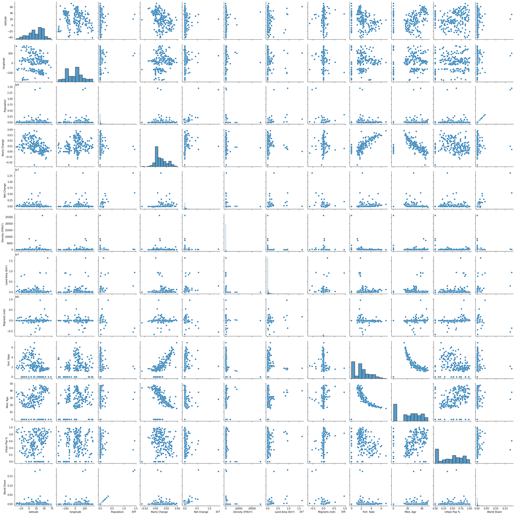

```python
# Pairplot
sns.pairplot(finaldf)
plt.show()
```

### Basemap

```python
# Extracting data for map
lat = finaldf['latitude'].values
lon = finaldf['longitude'].values
population = finaldf['Population'].values
density = finaldf['Density (P/Km²)'].values
```

```python
# Drawing map function
def draw_map(m, scale=0.2):
    # draw a shaded-relief image
    m.shadedrelief(scale=scale)

    # lats and longs are returned as a dictionary
    lats = m.drawparallels(np.linspace(-90, 90, 13))
    lons = m.drawmeridians(np.linspace(-180, 180, 13))

    # keys contain the plt.Line2D instances
    lat_lines = chain(*(tup[1][0] for tup in lats.items()))
    lon_lines = chain(*(tup[1][0] for tup in lons.items()))
    all_lines = chain(lat_lines, lon_lines)

    # cycle through these lines and set the desired style
    for line in all_lines:
        line.set(linestyle='-', alpha=0.3, color='w')
```

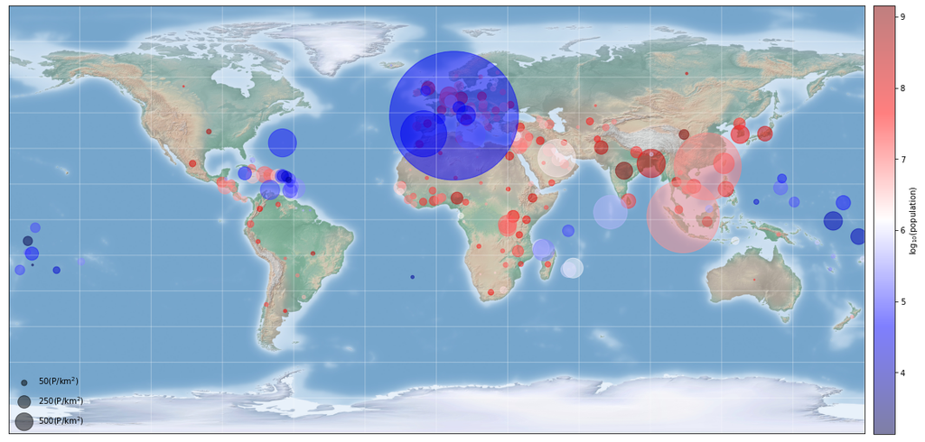

```python
# Drawing Basemap map visualization
fig = plt.figure(figsize=(20, 20), edgecolor='w')
m = Basemap(projection='cyl', resolution=None,
            llcrnrlat=-90, urcrnrlat=90,
            llcrnrlon=-180, urcrnrlon=180, )

m.scatter(lon, lat, latlon=True,
          c=np.log10(population), s=density,
          cmap='seismic', alpha=0.5)

plt.colorbar(fraction=0.0242, pad=0.01,label=r'$\log_{10}({\rm population})$')


for a in [50, 250, 500]:
    plt.scatter([], [], c='k', alpha=0.5, s=a,
                label=str(a) + '(P/km$^2)$')
plt.legend(scatterpoints=1, frameon=False,
           labelspacing=1, loc='lower left');


draw_map(m)
```

Larger the circle, the greater the population density. Blue is low population, up to dark red, being highest population.

### Interactive map

```python
world_map= folium.Map(tiles="cartodbpositron")

marker_cluster = MarkerCluster().add_to(world_map)

#for each coordinate, create circlemarker
for i in range(len(finaldf)):
        lat = finaldf.iloc[i]['latitude']
        long = finaldf.iloc[i]['longitude']
        radius=5
        popup_text = """
        Country/State : {}<br>
        Population : {}<br>
        Yearly Change : {}<br>
        Net Change : {}<br>
        Density (P/Km²) : {}<br>
        Land Area (Km²) : {}<br>
        Migrants (net) : {}<br>
        Fert. Rate : {}<br>
        Med. Age : {}<br>
        Urban Pop % : {}<br>
        World Share : {}<br>
        """
        popup_text = popup_text.format(
            finaldf.iloc[i]['Country'],
            finaldf.iloc[i]['Population'],
            finaldf.iloc[i]['Yearly Change'],
            finaldf.iloc[i]['Net Change'],
            finaldf.iloc[i]['Density (P/Km²)'],
            finaldf.iloc[i]['Land Area (Km²)'],
            finaldf.iloc[i]['Migrants (net)'],
            finaldf.iloc[i]['Fert. Rate'],
            finaldf.iloc[i]['Med. Age'],
            finaldf.iloc[i]['Urban Pop %'],
            finaldf.iloc[i]['World Share']
                                   )
        folium.CircleMarker(location = [lat, long], radius=radius, popup= popup_text, fill =True).add_to(marker_cluster)
#show the map
world_map
```

Make this Notebook Trusted to load map: File -> Trust Notebook

[interactive chart not shown]

### Predictions

```python
# First, dropping the variables we dont need for prediction, which is Country Code, Latitude, and Longitude
df = finaldf.drop(['country_code','latitude','longitude'], axis=1)
```

```python
# Encoding Country to numerical
from sklearn.preprocessing import OrdinalEncoder

ord_enc = OrdinalEncoder()
df["Country"] = ord_enc.fit_transform(df[["Country"]])
```

```python
df.head()
```

|  | Country | Population | Yearly Change | Net Change | Density (P/Km²) | Land Area (Km²) | Migrants (net) | Fert. Rate | Med. Age | Urban Pop % | World Share |
| --- | --- | --- | --- | --- | --- | --- | --- | --- | --- | --- | --- |
| 0 | 1.0 | 4903185 | 0.0 | 0.0 | 0.0 | 0.0 | 0.0 | 0.0 | 0.0 | 0.0 | 0.0 |
| 1 | 2.0 | 731545 | 0.0 | 0.0 | 0.0 | 0.0 | 0.0 | 0.0 | 0.0 | 0.0 | 0.0 |
| 2 | 11.0 | 7278717 | 0.0 | 0.0 | 0.0 | 0.0 | 0.0 | 0.0 | 0.0 | 0.0 | 0.0 |
| 3 | 12.0 | 3017804 | 0.0 | 0.0 | 0.0 | 0.0 | 0.0 | 0.0 | 0.0 | 0.0 | 0.0 |
| 4 | 37.0 | 39512223 | 0.0 | 0.0 | 0.0 | 0.0 | 0.0 | 0.0 | 0.0 | 0.0 | 0.0 |

```python
# Setting features
X = df.loc[:,df.columns != 'Country']
y = df['Country']
```

```python
import statsmodels.api as sm

Xc = sm.add_constant(X)
linear_regression = sm.OLS(y,Xc)
fitted_model = linear_regression.fit()
fitted_model.summary()
```

OLS Regression Results

| Dep. Variable: | Country | R-squared: | 0.037 |
| --- | --- | --- | --- |
| Model: | OLS | Adj. R-squared: | -0.002 |
| Method: | Least Squares | F-statistic: | 0.9472 |
| Date: | Fri, 03 Sep 2021 | Prob (F-statistic): | 0.490 |
| Time: | 17:05:52 | Log-Likelihood: | -1492.3 |
| No. Observations: | 261 | AIC: | 3007. |
| Df Residuals: | 250 | BIC: | 3046. |
| Df Model: | 10 |  |  |
| Covariance Type: | nonrobust |  |  |

|  | coef | std err | t | P>\|t\| | [0.025 | 0.975] |
| --- | --- | --- | --- | --- | --- | --- |
| const | 144.9072 | 11.523 | 12.575 | 0.000 | 122.212 | 167.602 |
| Population | -5.761e-07 | 1.34e-06 | -0.431 | 0.667 | -3.21e-06 | 2.06e-06 |
| Yearly Change | 356.2798 | 960.838 | 0.371 | 0.711 | -1536.089 | 2248.649 |
| Net Change | 2.807e-06 | 9.58e-06 | 0.293 | 0.770 | -1.61e-05 | 2.17e-05 |
| Density (P/Km²) | -0.0010 | 0.003 | -0.358 | 0.720 | -0.006 | 0.004 |
| Land Area (Km²) | -9.514e-07 | 3.67e-06 | -0.259 | 0.796 | -8.18e-06 | 6.28e-06 |
| Migrants (net) | 3.972e-05 | 5.11e-05 | 0.777 | 0.438 | -6.1e-05 | 0.000 |
| Fert. Rate | -2.5038 | 6.845 | -0.366 | 0.715 | -15.984 | 10.977 |
| Med. Age | 0.6322 | 0.504 | 1.255 | 0.211 | -0.360 | 1.625 |
| Urban Pop % | -57.7219 | 20.314 | -2.842 | 0.005 | -97.730 | -17.714 |
| World Share | 4246.9213 | 1.04e+04 | 0.407 | 0.684 | -1.63e+04 | 2.48e+04 |

| Omnibus: | 70.829 | Durbin-Watson: | 1.741 |
| --- | --- | --- | --- |
| Prob(Omnibus): | 0.000 | Jarque-Bera (JB): | 12.783 |
| Skew: | 0.004 | Prob(JB): | 0.00168 |
| Kurtosis: | 1.916 | Cond. No. | 2.95e+11 |

Notes:  
[1] Standard Errors assume that the covariance matrix of the errors is correctly specified.  
[2] The condition number is large, 2.95e+11. This might indicate that there are  
strong multicollinearity or other numerical problems.

```python
from sklearn.model_selection import train_test_split

X_train, X_test, y_train, y_test = train_test_split(X, y, test_size=0.3, random_state=42)
```

```python
from sklearn import metrics

def print_evaluate(true, predicted):
    mae = metrics.mean_absolute_error(true, predicted)
    mse = metrics.mean_squared_error(true, predicted)
    rmse = np.sqrt(metrics.mean_squared_error(true, predicted))
    r2_square = metrics.r2_score(true, predicted)
    print('MAE:', mae)
    print('MSE:', mse)
    print('RMSE:', rmse)
    print('R Sqaured', r2_square)

def evaluate(true, predicted):
    mae = metrics.mean_absolute_error(true, predicted)
    mse = metrics.mean_squared_error(true, predicted)
    rmse = np.sqrt(metrics.mean_squared_error(true, predicted))
    r2_square = metrics.r2_score(true, predicted)
    return mae, mse, rmse, r2_square
```

```python
from sklearn.preprocessing import StandardScaler
from sklearn.pipeline import Pipeline

pipeline = Pipeline([
    ('std_scalar', StandardScaler())
])

X_train = pipeline.fit_transform(X_train)
X_test = pipeline.transform(X_test)
```

```python
from sklearn.linear_model import LinearRegression

lin_reg = LinearRegression(normalize=True)
lin_reg.fit(X_train,y_train)
```

```
LinearRegression(normalize=True)
```

```python
coeff_df = pd.DataFrame(lin_reg.coef_, X.columns, columns=['Coefficient'])
coeff_df
```

|  | Coefficient |
| --- | --- |
| Population | -107.750684 |
| Yearly Change | 8.341085 |
| Net Change | -3.381163 |
| Density (P/Km²) | 0.171267 |
| Land Area (Km²) | -4.421363 |
| Migrants (net) | 7.689199 |
| Fert. Rate | -12.196901 |
| Med. Age | 15.864699 |
| Urban Pop % | -23.606201 |
| World Share | 110.225726 |

```python
pred = lin_reg.predict(X_test)
```

### Linear Regression

Simple and efficient model. Cons are the model assumes linearity between predictor and predicted varaibles, and the model can be overly simplistic. Outliers also can have a great affect on the model.

```python
test_pred = lin_reg.predict(X_test)
train_pred = lin_reg.predict(X_train)

print('Test set evaluation:')
print_evaluate(y_test, test_pred)
print('Train set evaluation:')
print_evaluate(y_train, train_pred)
```

```
Test set evaluation:
MAE: 65.18036652563373
MSE: 5869.550146032108
RMSE: 76.61298940801167
R Sqaured -0.08218601632060296
Train set evaluation:
MAE: 61.805846215098384
MSE: 5316.7298626797865
RMSE: 72.91590953063526
R Sqaured 0.06445493445582762
```

```python
results_df = pd.DataFrame(data=[["Linear Regression", *evaluate(y_test, test_pred)]],
                          columns=['Model', 'MAE', 'MSE', 'RMSE', 'R Squared'])
results_df
```

|  | Model | MAE | MSE | RMSE | R Squared |
| --- | --- | --- | --- | --- | --- |
| 0 | Linear Regression | 65.180367 | 5869.550146 | 76.612989 | -0.082186 |

### RANSAC

RANSAC (Random Sample consesus) data consists of "inliers", i.e., data whose distribution can be explained by some set of model parameters, though may be subject to noise, and "outliers" which are data that do not fit the model.

```python
from sklearn.linear_model import RANSACRegressor

model = RANSACRegressor(base_estimator=LinearRegression(), max_trials=100)
model.fit(X_train, y_train)

test_pred = model.predict(X_test)
train_pred = model.predict(X_train)

print('Test set evaluation:')
print_evaluate(y_test, test_pred)

print('Train set evaluation:')
print_evaluate(y_train, train_pred)
```

```
Test set evaluation:
MAE: 90.93191063982178
MSE: 13626.84650423017
RMSE: 116.73408458642305
R Sqaured -1.5124212872419527
Train set evaluation:
MAE: 99.7639246434937
MSE: 53400.16132470928
RMSE: 231.08474922571
R Sqaured -8.396425757357196
```

```python
results_df2 = pd.DataFrame(data=[["RANSAC Regression", *evaluate(y_test, test_pred)]],
                          columns=['Model', 'MAE', 'MSE', 'RMSE', 'R Squared'])

results_df = results_df.append(results_df2, ignore_index=True)

results_df
```

|  | Model | MAE | MSE | RMSE | R Squared |
| --- | --- | --- | --- | --- | --- |
| 0 | Linear Regression | 65.180367 | 5869.550146 | 76.612989 | -0.082186 |
| 1 | RANSAC Regression | 90.931911 | 13626.846504 | 116.734085 | -1.512421 |

### Ridge Regression

Ridge regression addresses some of the problems of Ordinary Least Squares by imposing a penalty on the size of coefficients.

```python
from sklearn.linear_model import Ridge

model = Ridge(alpha=100, solver='cholesky', tol=0.0001, random_state=42)
model.fit(X_train, y_train)
pred = model.predict(X_test)

test_pred = model.predict(X_test)
train_pred = model.predict(X_train)

print('Test set evaluation:')
print_evaluate(y_test, test_pred)
print('Train set evaluation')
print_evaluate(y_train, train_pred)
```

```
Test set evaluation:
MAE: 63.99190350026129
MSE: 5647.694903643538
RMSE: 75.15114705474254
R Sqaured -0.04128192060849267
Train set evaluation
MAE: 63.350899005277384
MSE: 5426.246042637965
RMSE: 73.66305751622019
R Sqaured 0.04518419390601902
```

```python
results_df3 = pd.DataFrame(data=[["Ridge Regression", *evaluate(y_test, test_pred)]],
                          columns=['Model', 'MAE', 'MSE', 'RMSE', 'R Squared'])

results_df = results_df.append(results_df3, ignore_index=True)

results_df
```

|  | Model | MAE | MSE | RMSE | R Squared |
| --- | --- | --- | --- | --- | --- |
| 0 | Linear Regression | 65.180367 | 5869.550146 | 76.612989 | -0.082186 |
| 1 | RANSAC Regression | 90.931911 | 13626.846504 | 116.734085 | -1.512421 |
| 2 | Ridge Regression | 63.991904 | 5647.694904 | 75.151147 | -0.041282 |

### Lasso Regression

A linear model that estimates sparse coefficients.

```python
from sklearn.linear_model import Lasso

model = Lasso(alpha=0.1,
              precompute=True,
#               warm_start=True,
              positive=True,
              selection='random',
              random_state=42)
model.fit(X_train, y_train)

test_pred = model.predict(X_test)
train_pred = model.predict(X_train)

print('Test set evaluation:')
print_evaluate(y_test, test_pred)
print('Train set evaluation:')
print_evaluate(y_train, train_pred)
```

```
Test set evaluation:
MAE: 63.78236093768173
MSE: 5583.587956220858
RMSE: 74.72340969348801
R Sqaured -0.029462336428481395
Train set evaluation:
MAE: 65.40196299486318
MSE: 5655.347859967446
RMSE: 75.20204691341483
R Sqaured 0.004870865930809876
```

```python
results_df4 = pd.DataFrame(data=[["Lasso Regression", *evaluate(y_test, test_pred)]],
                          columns=['Model', 'MAE', 'MSE', 'RMSE', 'R Squared'])

results_df = results_df.append(results_df4, ignore_index=True)

results_df
```

|  | Model | MAE | MSE | RMSE | R Squared |
| --- | --- | --- | --- | --- | --- |
| 0 | Linear Regression | 65.180367 | 5869.550146 | 76.612989 | -0.082186 |
| 1 | RANSAC Regression | 90.931911 | 13626.846504 | 116.734085 | -1.512421 |
| 2 | Ridge Regression | 63.991904 | 5647.694904 | 75.151147 | -0.041282 |
| 3 | Lasso Regression | 63.782361 | 5583.587956 | 74.723410 | -0.029462 |

### Elastic Net Regression

A linear regression model trained with L1 and L2 prior as regularizer.

This combination allows for learning a sparse model where few of the weights are non-zero like Lasso, while still maintaining the regularization properties of Ridge.

Elastic-net is useful when there are multiple features which are correlated with one another. Lasso is likely to pick one of these at random, while elastic-net is likely to pick both.

```python
from sklearn.linear_model import ElasticNet

model = ElasticNet(alpha=0.1, l1_ratio=0.9, selection='random', random_state=42)
model.fit(X_train, y_train)

test_pred = model.predict(X_test)
train_pred = model.predict(X_train)

print('Test set evaluation:')
print_evaluate(y_test, test_pred)
print('Train set evaluation:')
print_evaluate(y_train, train_pred)
```

```
Test set evaluation:
MAE: 64.85903455290658
MSE: 5814.614158186338
RMSE: 76.2536173449256
R Sqaured -0.07205730860700732
Train set evaluation:
MAE: 62.018185957977416
MSE: 5325.928074504679
RMSE: 72.97895638130679
R Sqaured 0.06283639412993813
```

```python
results_df5 = pd.DataFrame(data=[["Elastic Net Regression", *evaluate(y_test, test_pred)]],
                          columns=['Model', 'MAE', 'MSE', 'RMSE', 'R Squared'])

results_df = results_df.append(results_df5, ignore_index=True)

results_df
```

|  | Model | MAE | MSE | RMSE | R Squared |
| --- | --- | --- | --- | --- | --- |
| 0 | Linear Regression | 65.180367 | 5869.550146 | 76.612989 | -0.082186 |
| 1 | RANSAC Regression | 90.931911 | 13626.846504 | 116.734085 | -1.512421 |
| 2 | Ridge Regression | 63.991904 | 5647.694904 | 75.151147 | -0.041282 |
| 3 | Lasso Regression | 63.782361 | 5583.587956 | 74.723410 | -0.029462 |
| 4 | Elastic Net Regression | 64.859035 | 5814.614158 | 76.253617 | -0.072057 |

### Polynomial Regression

Linear regression model that is fitted with a quadratic curve

```python
from sklearn.preprocessing import PolynomialFeatures

poly_reg = PolynomialFeatures(degree=2)

X_train_2_d = poly_reg.fit_transform(X_train)
X_test_2_d = poly_reg.transform(X_test)

lin_reg = LinearRegression(normalize=True)
lin_reg.fit(X_train_2_d,y_train)

test_pred = lin_reg.predict(X_test_2_d)
train_pred = lin_reg.predict(X_train_2_d)

print('Test set evaluation:')
print_evaluate(y_test, test_pred)
print('Train set evaluation:')
print_evaluate(y_train, train_pred)
```

```
Test set evaluation:
MAE: 93.34177215189874
MSE: 23001.063291139242
RMSE: 151.66101440759007
R Sqaured -3.240772876095617
Train set evaluation:
MAE: 56.65384615384615
MSE: 4820.587912087912
RMSE: 69.4304537799366
R Sqaured 0.15175731123141512
```

```python
results_df6 = pd.DataFrame(data=[["Polynomial Regression", *evaluate(y_test, test_pred)]],
                          columns=['Model', 'MAE', 'MSE', 'RMSE', 'R Squared'])

results_df = results_df.append(results_df6, ignore_index=True)

results_df
```

|  | Model | MAE | MSE | RMSE | R Squared |
| --- | --- | --- | --- | --- | --- |
| 0 | Linear Regression | 65.180367 | 5869.550146 | 76.612989 | -0.082186 |
| 1 | RANSAC Regression | 90.931911 | 13626.846504 | 116.734085 | -1.512421 |
| 2 | Ridge Regression | 63.991904 | 5647.694904 | 75.151147 | -0.041282 |
| 3 | Lasso Regression | 63.782361 | 5583.587956 | 74.723410 | -0.029462 |
| 4 | Elastic Net Regression | 64.859035 | 5814.614158 | 76.253617 | -0.072057 |
| 5 | Polynomial Regression | 93.341772 | 23001.063291 | 151.661014 | -3.240773 |

### SGD Regression

Stochastic Gradient Descent it a very generic optimization algorithm capable of finding optimal solutions to a wide range of problems.

```python
from sklearn.linear_model import SGDRegressor

sgd_reg = SGDRegressor(n_iter_no_change=250, penalty=None, eta0=0.0001, max_iter=100000)
sgd_reg.fit(X_train, y_train)

test_pred = sgd_reg.predict(X_test)
train_pred = sgd_reg.predict(X_train)

print('Test set evaluation:')
print_evaluate(y_test, test_pred)
print('Train set evaluation:')
print_evaluate(y_train, train_pred)
```

```
Test set evaluation:
MAE: 64.59750271354096
MSE: 5761.984860808362
RMSE: 75.90773913645671
R Sqaured -0.0623538921178024
Train set evaluation:
MAE: 62.27918180531253
MSE: 5341.545155822971
RMSE: 73.08587521418191
R Sqaured 0.06008837349641161
```

```python
results_df7 = pd.DataFrame(data=[["SGD Regression", *evaluate(y_test, test_pred)]],
                          columns=['Model', 'MAE', 'MSE', 'RMSE', 'R Squared'])

results_df = results_df.append(results_df7, ignore_index=True)

results_df
```

|  | Model | MAE | MSE | RMSE | R Squared |
| --- | --- | --- | --- | --- | --- |
| 0 | Linear Regression | 65.180367 | 5869.550146 | 76.612989 | -0.082186 |
| 1 | RANSAC Regression | 90.931911 | 13626.846504 | 116.734085 | -1.512421 |
| 2 | Ridge Regression | 63.991904 | 5647.694904 | 75.151147 | -0.041282 |
| 3 | Lasso Regression | 63.782361 | 5583.587956 | 74.723410 | -0.029462 |
| 4 | Elastic Net Regression | 64.859035 | 5814.614158 | 76.253617 | -0.072057 |
| 5 | Polynomial Regression | 93.341772 | 23001.063291 | 151.661014 | -3.240773 |
| 6 | SGD Regression | 64.597503 | 5761.984861 | 75.907739 | -0.062354 |

### Neural Network

Finding fit through number of epochs

```python
from tensorflow.keras.models import Sequential
from tensorflow.keras.layers import Input, Dense, Activation, Dropout
from tensorflow.keras.optimizers import Adam

X_train = np.array(X_train)
X_test = np.array(X_test)
y_train = np.array(y_train)
y_test = np.array(y_test)

model = Sequential()

model.add(Dense(X_train.shape[1], activation='relu'))
model.add(Dense(32, activation='relu'))
# model.add(Dropout(0.2))

model.add(Dense(64, activation='relu'))
# model.add(Dropout(0.2))

model.add(Dense(128, activation='relu'))
# model.add(Dropout(0.2))

model.add(Dense(512, activation='relu'))
model.add(Dropout(0.1))
model.add(Dense(1))

model.compile(optimizer=Adam(0.00001), loss='mse')

r = model.fit(X_train, y_train,
              validation_data=(X_test,y_test),
              batch_size=1,
              epochs=100)
```

```python
test_pred = model.predict(X_test)
train_pred = model.predict(X_train)

print('Test set evaluation:')
print_evaluate(y_test, test_pred)

print('Train set evaluation:')
print_evaluate(y_train, train_pred)
```

```
Test set evaluation:
MAE: 67.55174680299396
MSE: 6475.5822955990225
RMSE: 80.47100282461393
R Sqaured -0.19392192476077308
Train set evaluation:
MAE: 66.72224275358431
MSE: 6377.79557169971
RMSE: 79.86110174358798
R Sqaured -0.12225283778960705
```

```python
results_df8 = pd.DataFrame(data=[["AI Regression", *evaluate(y_test, test_pred)]],
                          columns=['Model', 'MAE', 'MSE', 'RMSE', 'R Squared'])

results_df = results_df.append(results_df8, ignore_index=True)

results_df
```

|  | Model | MAE | MSE | RMSE | R Squared |
| --- | --- | --- | --- | --- | --- |
| 0 | Linear Regression | 65.180367 | 5869.550146 | 76.612989 | -0.082186 |
| 1 | RANSAC Regression | 90.931911 | 13626.846504 | 116.734085 | -1.512421 |
| 2 | Ridge Regression | 63.991904 | 5647.694904 | 75.151147 | -0.041282 |
| 3 | Lasso Regression | 63.782361 | 5583.587956 | 74.723410 | -0.029462 |
| 4 | Elastic Net Regression | 64.859035 | 5814.614158 | 76.253617 | -0.072057 |
| 5 | Polynomial Regression | 93.341772 | 23001.063291 | 151.661014 | -3.240773 |
| 6 | SGD Regression | 64.597503 | 5761.984861 | 75.907739 | -0.062354 |
| 7 | AI Regression | 67.551747 | 6475.582296 | 80.471003 | -0.193922 |

### Random Forest

It reduces overfitting in decision trees and helps to improve the accuracy, however It requires much computational power as well as resources as it builds numerous trees to combine their outputs.

```python
from sklearn.ensemble import RandomForestRegressor

rf_reg = RandomForestRegressor(n_estimators=1000)
rf_reg.fit(X_train, y_train)

test_pred = rf_reg.predict(X_test)
train_pred = rf_reg.predict(X_train)

print('Test set evaluation:')
print_evaluate(y_test, test_pred)

print('Train set evaluation:')
print_evaluate(y_train, train_pred)
```

```
Test set evaluation:
MAE: 73.16929113924053
MSE: 7317.065309367088
RMSE: 85.53984632536516
R Sqaured -0.3490685932131625
Train set evaluation:
MAE: 26.838620879120885
MSE: 992.6881387857145
RMSE: 31.50695381635163
R Sqaured 0.8253241157907711
```

```python
results_df9 = pd.DataFrame(data=[["Random Forest Regression", *evaluate(y_test, test_pred)]],
                          columns=['Model', 'MAE', 'MSE', 'RMSE', 'R Squared'])

results_df = results_df.append(results_df9, ignore_index=True)

results_df
```

|  | Model | MAE | MSE | RMSE | R Squared |
| --- | --- | --- | --- | --- | --- |
| 0 | Linear Regression | 65.180367 | 5869.550146 | 76.612989 | -0.082186 |
| 1 | RANSAC Regression | 90.931911 | 13626.846504 | 116.734085 | -1.512421 |
| 2 | Ridge Regression | 63.991904 | 5647.694904 | 75.151147 | -0.041282 |
| 3 | Lasso Regression | 63.782361 | 5583.587956 | 74.723410 | -0.029462 |
| 4 | Elastic Net Regression | 64.859035 | 5814.614158 | 76.253617 | -0.072057 |
| 5 | Polynomial Regression | 93.341772 | 23001.063291 | 151.661014 | -3.240773 |
| 6 | SGD Regression | 64.597503 | 5761.984861 | 75.907739 | -0.062354 |
| 7 | AI Regression | 67.551747 | 6475.582296 | 80.471003 | -0.193922 |
| 8 | Random Forest Regression | 73.169291 | 7317.065309 | 85.539846 | -0.349069 |

### Support Vector Machines

It works really well with a clear margin of separation It is effective in high dimensional spaces. However, It doesn’t perform well when we have large data set because the required training time is higher It also doesn’t perform very well, when the data set has more noise i.e. target classes are overlapping

```python
from sklearn.svm import SVR

svm_reg = SVR(kernel='rbf', C=1000000, epsilon=0.001)
svm_reg.fit(X_train, y_train)

test_pred = svm_reg.predict(X_test)
train_pred = svm_reg.predict(X_train)

print('Test set evaluation:')
print_evaluate(y_test, test_pred)

print('Train set evaluation:')
print_evaluate(y_train, train_pred)
```

```
Test set evaluation:
MAE: 200.4489376869145
MSE: 114422.70764607783
RMSE: 338.2642571216738
R Sqaured -20.096447101288398
Train set evaluation:
MAE: 17.41012991496921
MSE: 1588.6782179024485
RMSE: 39.85822647713328
R Sqaured 0.7204522129422206
```

```python
results_df10 = pd.DataFrame(data=[["SVM Regression", *evaluate(y_test, test_pred)]],
                          columns=['Model', 'MAE', 'MSE', 'RMSE', 'R Squared'])

results_df = results_df.append(results_df10, ignore_index=True)

results_df
```

|  | Model | MAE | MSE | RMSE | R Squared |
| --- | --- | --- | --- | --- | --- |
| 0 | Linear Regression | 65.180367 | 5869.550146 | 76.612989 | -0.082186 |
| 1 | RANSAC Regression | 90.931911 | 13626.846504 | 116.734085 | -1.512421 |
| 2 | Ridge Regression | 63.991904 | 5647.694904 | 75.151147 | -0.041282 |
| 3 | Lasso Regression | 63.782361 | 5583.587956 | 74.723410 | -0.029462 |
| 4 | Elastic Net Regression | 64.859035 | 5814.614158 | 76.253617 | -0.072057 |
| 5 | Polynomial Regression | 93.341772 | 23001.063291 | 151.661014 | -3.240773 |
| 6 | SGD Regression | 64.597503 | 5761.984861 | 75.907739 | -0.062354 |
| 7 | AI Regression | 67.551747 | 6475.582296 | 80.471003 | -0.193922 |
| 8 | Random Forest Regression | 73.169291 | 7317.065309 | 85.539846 | -0.349069 |
| 9 | SVM Regression | 200.448938 | 114422.707646 | 338.264257 | -20.096447 |

## Data Summary and Implications

Can the geographic location be accurately predicted based on variables such as population density, net gain or loss of migrants, fertility rate, etc? The alternate hypothesis is correct in that the geographic location CANNOT be accurately predicted based on these variables.

We ran 10 different regression variations and the accuracy is quite low on all of them. The RMSE shows the best functions are Linear, Ridge, Elastic, Lasso, SGD, AI, and Random Forest. However, even on all of these, the R Squared scores are negative, meaning the outcome results are not reliable.

One limitation of this analysis is the data has many 0 values. There were many null values and NaN values. All of these values may have had a significant affect on the accuracy of the analysis. If there was more data filled about each and every country, the analysis may have been able to predict with much higher accuracy. However, the abundance of 0 values really made the accuracy very low and unreliable in being able to predict location. In redoing this analysis, much more complete data would need to be put together on every country involved in the study in order to run another analysis.

A course of action based on these results would be to find more sources of data to add to the data collected for this analysis. The more data that is added, the more accurate the total results will be. Finding data to fill in the blanks in this dataset would help significantly in increasing accuracy.

One direction for future study of this dataset could be finding the fertility rate of certain countries and tracking the changing fertility rates of those countries over time. Another avenue for study could be tracking the population over time, and tracking the population densities, and the urban population percentages, and seeing how the population moves around between urban and rural areas.